# Geomorfología. Asignaciones del tema 4: procesos fluviales. Parte 1

## Léeme

Dentro de las opciones de `knitr`, en el encabezado de este archivo, es probable que encuentres el argumento `eval = F`. Antes de tejer debes cambiarlo a `eval = T`, para que evalúe los bloques de código según tus cambios.

## Recursos en línea sobre GRASS GIS para geomorfología

[GRASS GIS for geomorphologists. Andrew Wickert](https://github.com/awickert/GRASS-GIS-for-geomorphologists)

[Geomorphology in GRASS GIS. A ‘how-to’ manual. Skyler Sorsby](https://es.slideshare.net/SkylerSorsby/introduction-to-geomorphology-in-grass-gis-by-skyler-sorsby)

[Funciones creadas por el profesor](https://github.com/geofis/rgrass)

[Lista de recursos de pago](https://grass.osgeo.org/documentation/books/)

## Datos asignados a cada estudiante

### Coordenadas de desembocadura de cuenca

```r
 # abreviatura     coordenada de desembocadura (EPSG:32619)
 #       anala     311450,2109960
 #       carol     292900,2124790
 #       danie     288280,2093570
```

### Nombres geográficos

```r
 # abreviatura     nombre geográfico                     abreviatura de nombre geográfico
 #       anala     Río Yaque del Norte, hasta Manabao    rioydn
 #       carol     Río Bao, hasta Mata Grande            riobao
 #       danie     Río Yaque del Sur, hasta P. Palomino  rioyds
```

### DEMs

```r
 # abreviatura     ruta de archivo DEM
 #       anala     mi-asignacion/data-asignada/demydn.tif
 #       carol     mi-asignacion/data-asignada/dembao.tif
 #       danie     mi-asignacion/data-asignada/demyds.tif
```

### Límites de cuencas vectorizados

```r
 # abreviatura     ruta de archivo DEM
 #       anala     mi-asignacion/data-asignada/cuenca_rio_yaque_del_norte.geojson
 #       carol     mi-asignacion/data-asignada/cuenca_rio_bao.geojson
 #       danie     mi-asignacion/data-asignada/cuenca_rio_yaque_del_sur.geojson
```

## Ejercicios

### Ejercicio 1: Crea una región de GRASS. Redacta de forma resumida el procedimiento, cita ventajas/desventajas

[**Vídeo de referencia**](https://www.youtube.com/watch?v=cORbTaa827g&list=PLDcT2n8UzsCSt1-NnUQ8anwHhmouFr0Kv&index=5)

**Script de referencia**

Dentro del bloque de código a continuación, carga el paquete `rgrass7` y crea una región de GRASS GIS utilizando los atributos correspondientes en cada parámetro:

- Ruta de inicio (parámetro `home`): `mi-asignacion`
- Nombre del directorio de la base de datos de GRASS GIS (parámetro `gisDbase`): utiliza `mi-asignacion/mi-grass`
- Nombre de localidad (parámetro `location`): usa la abreviatura de nombre geográfico que te tocó.
- Nombre del conjunto de mapas (parámetro `mapset`): utiliza `PERMANENT`

> **IMPORTANTE**. Asegúrate que tus parámetros no tengan espacios, signos de puntuación, o tildes.
- Verifica la metadata de tu región con la función `gmeta`.

```r
library(rgrass7)
```

```r
loc <- initGRASS(gisBase = "/usr/lib/grass78/",
                 home = 'mi-asignacion',
                 gisDbase = 'mi-asignacion/mi-grass',
                 location = 'rioydn',
                 mapset = 'PERMANENT',
                 override = TRUE)
```

*Describe, en un párrafo, usando tus propias palabras, el procedimiento que acabas de ejecutar. Si aplica, en un párrafo adicional, plantea las ventajas y desventajas de usar GRASS desde R*

Se creó una carpeta de inicio, cargando una ruta de datos para trabajar en GRASS desde Rstudio la cual puede almacenar distintos datos, desde mapas, tablas de atributos, entre otras informaciones.

### EJERCICIO 2: Define resolución/extensión utilizando una fuente. Redacta de forma resumida el procedimiento

[**Vídeo de referencia**](https://www.youtube.com/watch?v=YkqHMeko8-Y&list=PLDcT2n8UzsCSt1-NnUQ8anwHhmouFr0Kv&index=6)

**Script de referencia**

Escribe el código necesario para definir la proyección de tu región de GRASS creada en el ejercicio anterior, usando como referencia tu DEM asignado. Usa el vídeo de referencia para conocer los pasos necesarios. El procedimiento general consiste en:

- Sin importarlo (aún), usa tu DEM para definir la proyección de la región de GRASS (addon `g.proj`).
- Importa el DEM (addon `r.in.gdal`).
- Utilízalo para definir la extensión y resolución de la región de GRASS (addon `g.region`)
- Verifica la metadata de tu región con la función `gmeta`.

```r
gmeta()
## gisdbase    mi-asignacion/mi-grass
## location    rioydn
## mapset      PERMANENT
## rows        134
## columns     197
## north       2113052
## south       2101040
## west        293837.2
## east        311497.1
## nsres       89.64434
## ewres       89.64434
## projection  +proj=utm +no_defs +zone=19 +a=6378137 +rf=298.257223563
## +towgs84=0.000,0.000,0.000 +type=crs +to_meter=1
dem <-'mi-asignacion/data-asignada/demydn.tif'
execGRASS(
 cmd = 'g.proj',
 flags = c('t','c'),
  georef=dem
)
## Projection information updated

gmeta()
## gisdbase    mi-asignacion/mi-grass
## location    rioydn
## mapset      PERMANENT
## rows        134
## columns     197
## north       2113052
## south       2101040
## west        293837.2
## east        311497.1
## nsres       89.64434
## ewres       89.64434
## projection  +proj=utm +no_defs +zone=19 +a=6378137 +rf=298.257223563
## +towgs84=0.000,0.000,0.000 +type=crs +to_meter=1

execGRASS(
  cmd = 'r.in.gdal',
  flags=c('overwrite','quiet'),
  parameters=list(
    input=dem,
    output='Yaque_dem'
  )
)
execGRASS(
  cmd = 'g.region',
  parameters=list(
    raster = 'Yaque_dem',
    align = 'Yaque_dem'
  )
)

execGRASS(
  'g.list',
  flags = 't',
  parameters = list(
    type = c('raster', 'vector')
  )
)
## raster/MASK
## raster/Yaque_dem
## raster/accum-de-rwshed
## raster/aspect
## raster/basins
## raster/drainage-dir-de-rwshed
## raster/half-basins
## raster/pcurv
## raster/red30
## raster/red80
## raster/slope
## raster/stream-de-rwshed
## raster/tcurv
## raster/yaquenorte_basin
## vector/red30
## vector/red80
## vector/yaque_v
## vector/yaquenorte_basin

gmeta()
## gisdbase    mi-asignacion/mi-grass
## location    rioydn
## mapset      PERMANENT
## rows        325
## columns     363
## north       2122107
## south       2092972
## west        287831
## east        320371.9
## nsres       89.64434
## ewres       89.64434
## projection  +proj=utm +no_defs +zone=19 +a=6378137 +rf=298.257223563
## +towgs84=0.000,0.000,0.000 +type=crs +to_meter=1
```

*Describe, en un párrafo, usando tus propias palabras, el procedimiento que acabas de ejecutar*

Se creó una carpeta en Grass, en la cual se introdujo un dem o modelo digital de elevación con una ruta asignada. Donde dicha carpeta guardará los mapas realisados en Rstudio al igaul que los ejecutados desde Grass.

### EJERCICIO 3: Explora y compara mapas de GRASS y R. Interpreta el resultado

[**Vídeo de referencia**](https://www.youtube.com/watch?v=w5lGrm_XKek&list=PLDcT2n8UzsCSt1-NnUQ8anwHhmouFr0Kv&index=7)

**Script de referencia**

Explora y compara mapas de pendientes generados en R y en GRASS. Usa el vídeo de referencia para conocer los pasos necesarios. El procedimiento general consiste en:

- Antes que nada, explora qué mapas están disponibles en tu región de GRASS mediante el addon `g.list`.
- **En R**:
  - Carga los paquetes `sp` y `raster`, y ejecuta la función `use_sp()`; esto preparará a R para definir que los mapas de GRASS que importes con el paquete `rgrass7` serán objetos `Spatial*` y `Raster*`.
  - Importa el DEM desde la región de GRASS mediante la función `readRAST`. Convierte tu DEM a raster con la función `raster` (puedes también hacerlo en un único paso ejecutando `raster(readRAST(Yaque))`). Representa tu raster con la función `plot`.
  - Importa tu límite de cuenca a R. Para ello, carga el paquete `sf`, importa el archivo del límite de tu cuenca con la función `st_read`. Represéntalo con la función `plot` pero añadiendo el argumento `add=T`, para que se superponga sobre el DEM.
  - Usando el límite de cuenca, corta el DEM con la función `crop`, y enmascáralo con `mask`.
  - Genera un mapa de pendiente en R a partir del DEM con la función `terrain` del paquete `raster`.
  - Finalmente, representa el mapa de pendiente con `plot`, e igualmente haz un histograma de dicha variable y calcula sus estadísticos descriptivos básicos con `summary`. Compararás el mapa y los estadísticos de pendiente con los resultados que obtengas en GRASS.
- **En GRASS (recuerda, “desde R”)**. Lleva tu límite de cuenca a la región de GRASS y úsalo como máscara. Genera un mapa de pendiente, y tráelo a R. Te recomiendo el siguiente procedimiento:
  - Lleva tu límite de cuenca a la región (vectorial formato GeoJSON) de GRASS mediante la función `writeVECT`.
  - Define los límites de la región de GRASS usando dicho vectorial mediante el addon `g.region`.
  - Utiliza el vectorial como máscara de la región mediante el addon `r.mask`.
  - Utiliza el addon `r.slope.aspect` para crear un mapa de pendientes a partir del DEM.
  - Trae el mapa raster de pendientes generado en GRASS a R mediante `raster(readRAST(...))`.
  - Represéntalo mediante la función `plot`.

> **Nota sobre la máscara**. Si al ejecutar el addon `g.list` uno de los mapas de denomina `raster/MASK`, como en el ejemplo a continuación, quiere decir que hay una máscara aplicada, con lo que todos los algoritmos se ejecutan únicamente dentro de dicha área.

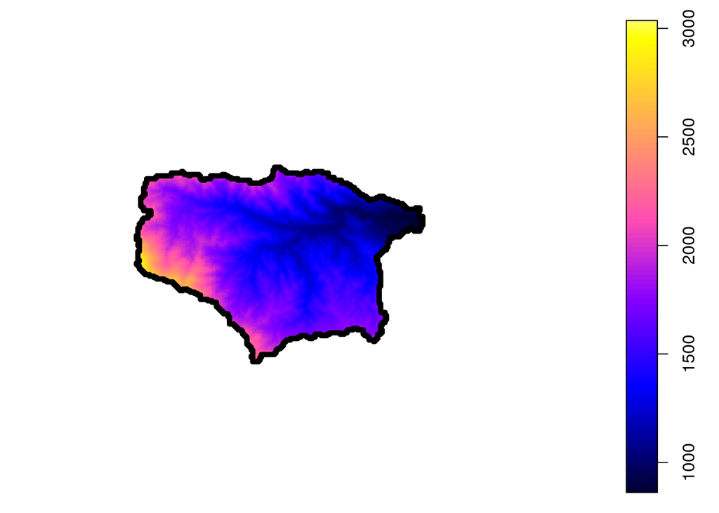

```r
execGRASS(
  'g.list',
  flags = 't',
  parameters = list(
    type = c('raster', 'vector')
  )
)
## raster/MASK
## raster/Yaque_dem
## raster/accum-de-rwshed
## raster/aspect
## raster/basins
## raster/drainage-dir-de-rwshed
## raster/half-basins
## raster/pcurv
## raster/red30
## raster/red80
## raster/slope
## raster/stream-de-rwshed
## raster/tcurv
## raster/yaquenorte_basin
## vector/red30
## vector/red80
## vector/yaque_v
## vector/yaquenorte_basin

library(sp)
use_sp ()
yaque_sp  <- (readRAST('Yaque_dem'))
## Creating BIL support files...
## Exporting raster as floating values (bytes=4)
##    0%   3%   6%   9%  12%  15%  18%  21%  24%  27%  30%  33%  36%  39%  42%  45%  48%  51%  54%  57%  60%  63%  66%  69%  72%  75%  78%  81%  84%  87%  90%  93%  96%  99% 100%
plot (yaque_sp)

library ( sf )
## Linking to GEOS 3.8.0, GDAL 3.0.4, PROJ 7.0.0
rutayaquenorte  <-  'mi-asignacion/data-asignada/cuenca_rio_yaque_del_norte.geojson'
yaquenorte  <- st_read (rutayaquenorte)
## Reading layer `cuenca_rio_yaque_del_norte' from data source `/home/analaroja29/unidad-4-asignacion-1-procesos-fluviales-parte-1-anavalera29/mi-asignacion/data-asignada/cuenca_rio_yaque_del_norte.geojson' using driver `GeoJSON'
## Simple feature collection with 1 feature and 1 field
## geometry type:  POLYGON
## dimension:      XY
## bbox:           xmin: 293837.2 ymin: 2101040 xmax: 311497.1 ymax: 2113052
## projected CRS:  WGS 84 / UTM zone 19N
plot (yaquenorte , add = T , col = 'transparent' , border = 'black' , lwd = 5 )
```

[figure not shown]

```r
library(raster)
dem_y0  <- raster(yaque_sp)
dem_y1  <- crop(dem_y0 , yaquenorte)
dem_yaque  <- mask (dem_y1 , yaquenorte)
plot (dem_yaque)
```

[figure not shown]

```r
dem_yaquep_r  <-  terrain(x  =  dem_yaque, opt = 'slope', unit = 'degrees')
plot (dem_yaquep_r)
hist (dem_yaquep_r)
```

[output not shown]

```r
summary(dem_yaquep_r)
```

```
##                slope
## Min.    2.348902e-01
## 1st Qu. 1.263330e+01
## Median  1.770662e+01
## 3rd Qu. 2.337461e+01
## Max.    4.408737e+01
## NA's    1.040300e+04
```

```r
writeVECT (as_Spatial (yaquenorte), 'yaque_v' , v.in.ogr_flags = c('quiet', 'overwrite'))
execGRASS(
  cmd = 'g.region',
  parameters = list(
     vector = 'yaque_v'
  )
)

execGRASS (
  "r.mask",
  flags = c('overwrite','quiet'),
   parameters = list(
     vector = 'yaque_v'
  )
)
```

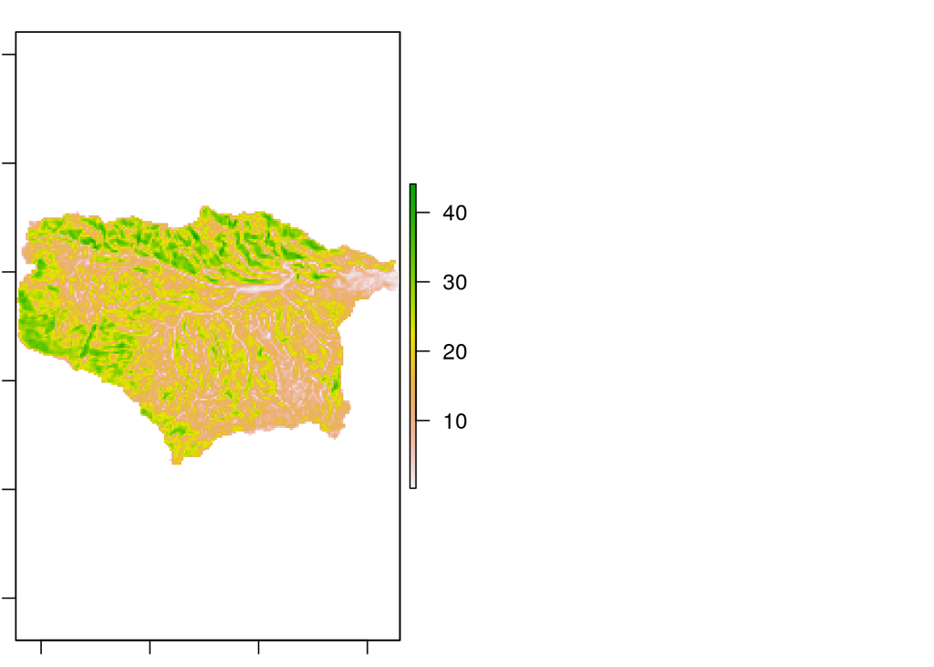

```r
execGRASS (
  cmd  =  'r.slope.aspect',
  flags = c('overwrite','quiet'),
   parameters = list(
     elevation = 'Yaque_dem',
     slope = 'slope' ,
     aspect = 'aspect',
     pcurvature = 'pcurv',
     tcurvature = 'tcurv')
  )

dem_yaquep_g <- raster(readRAST('slope'))
## Creating BIL support files...
## Exporting raster as floating values (bytes=4)
##    0%   3%   6%   9%  12%  15%  18%  21%  24%  27%  30%  33%  36%  39%  42%  45%  48%  51%  54%  57%  60%  63%  66%  69%  72%  75%  78%  81%  84%  87%  90%  93%  96%  99% 100%
plot (dem_yaquep_g); par(mfrow=c(1,1))
```

- **En R nuevamente**. Compara los estadísticos descriptivos de los dos mapas de pendiente, es decir, del generado en R y del generado en GRASS, mediante la función `summary`. Genera también un histograma de los valores de pendiente (función `hist`), así como dos mapas de pendiente mediante la función `plot`. Para colocar ambos histogramas o ambos mapas enfrentados, usa `par(mfrow=c(1,2))`, de manera que tu dispositivo gráfico quedará dividido en dos columnas en lo adelante. Si deseas volver a ponerlo en modo 1 columna, ejecuta `par(mfrow=c(1,1))`. Teniendo los histogramas y los mapas enfrentados, podrás interpretar mejor tus resultados.
- **En GRASS desde R**. No olvides volver a poner la región de GRASS a su estado anterior, quitando la máscara (addon `r.mask`) y utilizando la extensión del DEM como límite de la región (addon `g.region`). Puedes comprobar que no hay máscara aplicada si al ejecutar el addon `g.list` NO te aparece el mapa `raster/MASK`.

```r
summary(dem_yaquep_r)
```

```
##                slope
## Min.    2.348902e-01
## 1st Qu. 1.263330e+01
## Median  1.770662e+01
## 3rd Qu. 2.337461e+01
## Max.    4.408737e+01
## NA's    1.040300e+04
```

```r
summary(dem_yaquep_g)
```

```
##                slope
## Min.       0.2348902
## 1st Qu.   12.4806499
## Median    17.5676231
## 3rd Qu.   23.2384739
## Max.      44.0873718
## NA's    9635.0000000
```

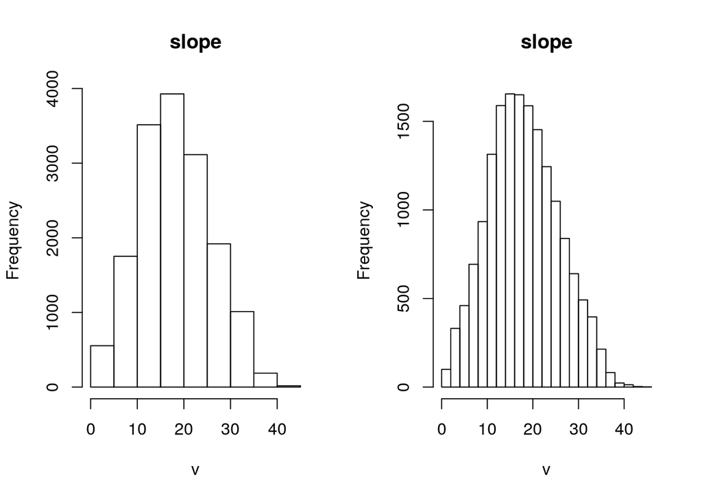

```r
par(mfrow=c(1,2))
hist (dem_yaquep_r)
hist (dem_yaquep_g)
```

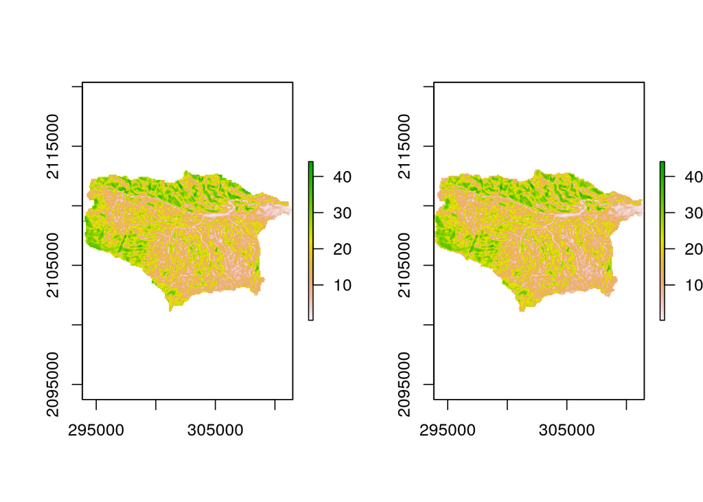

```r
plot (dem_yaquep_r)
plot (dem_yaquep_g)
```

```r
execGRASS(
  "g.region",
  parameters=list(
    raster = "Yaque_dem"
  )
)
execGRASS(
  "r.mask",
  flags = c('r','quiet')
)
```

*Tu párrafo interpretativo debajo de esta línea. Algunas preguntas clave: ¿Hay diferencias? ¿Son significativas? ¿Notas diferencias entre ambos mapas de pendiente en algunas áreas más que en otras?*

Este ejercio consistió en explorar mapas o modelos digitales de elevaciones desde grass en r y viceversa, donde se ejecutaron varios comando en cada caso. Como por ejemplo, definir una región e introducir en ambas un raster y un vector, a partir de las informaciones establecidas.

### EJERCICIO 4: Extrae el límite de tu cuenca hidrográfica. Descríbelo

[**Vídeo de referencia sobre `r.watershed`**](https://www.youtube.com/watch?v=gPDf6w3NOgs&list=PLDcT2n8UzsCSt1-NnUQ8anwHhmouFr0Kv&index=8)

[**Script de referencia sobre `r.watershed`**](https://github.com/geomorfologia-master/unidad-4-asignacion-1-procesos-fluviales/blob/master/calcular-parametros-hidrograficos-r-watershed.Rmd)

[**Vídeo de referencia sobre `r.water.outlet`**](https://www.youtube.com/watch?v=gPDf6w3NOgs&list=PLDcT2n8UzsCSt1-NnUQ8anwHhmouFr0Kv&index=9)

[**Script de referencia sobre `r.water.outlet`**](https://github.com/geomorfologia-master/unidad-4-asignacion-1-procesos-fluviales/blob/master/crear-una-cuenca-con-r-water-outlet.Rmd)

- Usando el addon de GRASS `r.watershed`, genera un mapa de dirección de drenaje. Lo necesitarás para generar el mapa de cuenca en el siguiente paso. Es posible hacer lo propio con el addon `r.stream.extract`.
- Ejecuta el addon `r.water.outlet` para generar el límite de tu cuenca, usando el mapa de dirección generado en el paso anterior, especificando las coordenadas de desembocadura de tu cuenca. La salida del módulo (parámetro `output`), es un mapa ráster donde el área de tu cuenca tiene valor 1.
- Vectoriza tu límite de cuenca en GRASS mediante el módulo `r.to.vect`.
- Define los límites de la región de GRASS usando dicho vectorial mediante el addon `g.region`.
- Utiliza el vectorial como máscara de la región mediante el addon `r.mask`.

> **Nota**. Puedes conservar tu región de GRASS con la máscara actual, de manera que todos tus análisis, desde este ejercicio en adelante, se referirán únicamente a tu cuenca asignada. Por lo tanto, NO quites la máscara, consérvala para futuros ejercicios. Para comprobar si hay o no máscara aplicada, ejecuta el addon `g.list`; si te aparece el mapa `raster/MASK`, significa que la hay.
- Haz un plot de tu cuenca sobre el DEM. Para ello, primero representa el DEM mediante la función `plot` (el DEM fue importado a R en ejercicios anteriores, por lo que puedes usar el objeto ya creado o ejecutar nuevamente el código que lo importó).
- Importa el límite de tu cuenca a R con la función `readVECT`, y luego superpones dicho límite al DEM mediante `plot(<nombredelvectorial>, add=T)` (el argumento `add` es la clave).
- Haz también un mapa de tu cuenca con la función `mapview` del paquete homónimo.

```r
execGRASS(
  "r.watershed",
  flags = c('quiet', 'overwrite'),
  parameters = list(
    elevation = "Yaque_dem",
    accumulation = "accum-de-rwshed",
    stream = "stream-de-rwshed",
    drainage = "drainage-dir-de-rwshed",
    basin = 'basins',
    half_basin = 'half-basins',
    threshold = 80
  )
)

yaquen_out <- c(311450,2109960)
yaquen_out
```

```
## [1]  311450 2109960
```

```r
execGRASS(
  "r.water.outlet",
  flags = c('quiet', 'overwrite'),
  parameters = list(
    input = 'drainage-dir-de-rwshed',
    output = 'yaquenorte_basin',
    coordinates = yaquen_out
  )
)

execGRASS(
  "r.to.vect",
  flags = c('quiet', 'overwrite'),
  parameters = list(
    input = 'yaquenorte_basin',
    output = 'yaquenorte_basin',
    type = 'area'
  )
)
```

[interactive chart not shown]

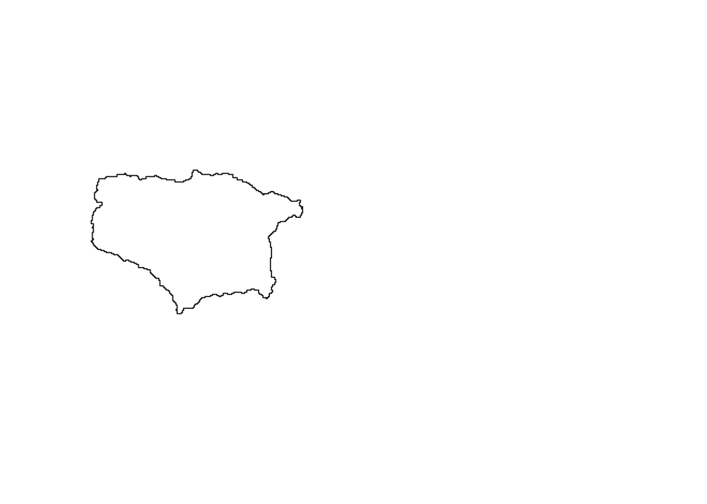

```r
execGRASS(
  cmd = 'g.region',
  parameters = list(
     vector  =  "yaquenorte_basin"
  )
)

execGRASS (
  "r.mask",
   parameters = list(
     vector = 'yaquenorte_basin'
  )
)
## Reading areas...
##    0% 100%
## Writing raster map...
##    0%   3%   6%   9%  12%  15%  18%  21%  24%  27%  30%  33%  36%  39%  42%  45%  48%  51%  54%  57%  60%  63%  66%  69%  72%  75%  78%  81%  84%  87%  90%  93%  96%  99% 100%
## All subsequent raster operations will be limited to the MASK area. Removing
## or renaming raster map named 'MASK' will restore raster operations to
## normal.

par(mfrow=c(1,2))

yaque_bas <- readVECT('yaquenorte_basin')
## Exporting 1 area (may take some time)...
##  100%
## v.out.ogr complete. 1 feature (Polygon type) written to <yaquenorte_basin>
## (GPKG format).
## OGR data source with driver: GPKG
## Source: "/home/analaroja29/unidad-4-asignacion-1-procesos-fluviales-parte-1-anavalera29/mi-asignacion/mi-grass/rioydn/PERMANENT/.tmp/rstudio-ubuntu-s-1vcpu-2gb-nyc3-01/725.0.gpkg", layer: "yaquenorte_basin"
## with 1 features
## It has 3 fields
yaque_bas
## class       : SpatialPolygonsDataFrame
## features    : 1
## extent      : 293837.2, 311497.1, 2101040, 2113052  (xmin, xmax, ymin, ymax)
## crs         : +proj=utm +zone=19 +datum=WGS84 +units=m +no_defs +ellps=WGS84 +towgs84=0,0,0
## variables   : 3
## names       : cat, value, label
## value       :   1,     1,
plot(yaque_bas)

library(mapview)
mapview(yaque_bas)
```

*Describe, en términos morfométricos, el límite de tu cuenca y abunda sobre ella. Algunas preguntas guía: ¿Qué forma tiene? ¿A qué atribuyes su forma? ¿Es importante esta cuenca? ¿Por qué?*

La cuenca del río Yaque del Norte posee una pendiente probablemente media alta, lo que indica aparentemente que el relieve es accidentado.Tambien los flujos fluviales que alimentan el canal principal presentan cursos largos. Dicha región, presenta una forma convexa, a lo que se le puede atribuir a las diferentes elevaciones que presenta su pendiente. Posiblemente por encontrarse entre el medio de dos sistemas montañosos (cordillera central y sierra septentrional). La cuenca del río Yaque del Norte es la más importante del país, según varios estudio. Posee el río más largo del país e importantes presas hidroeléctricas se han establecido en su área, además, de la gran biodiversidad que tienen como hábitat ese ambiente natural.

### EJERCICIO 5: Extrae la red de drenaje de tu cuenca utilizando dos umbrales de acumulación distintos. Describe e interpreta los resultados.

[**Vídeo de referencia**](https://www.youtube.com/watch?v=17MRQTJ4gUU&list=PLDcT2n8UzsCSt1-NnUQ8anwHhmouFr0Kv&index=10)

**Script de referencia**

Usando el addon de GRASS `r.stream.extract`, realiza las siguientes tareas:

> **Recuerda**. Si conservaste la región de GRASS y la máscara que estableciste en el ejercicio anterior, los nuevos mapas que generes se referirán únicamente a tu cuenca asignada. Para saber si tu región tiene máscara aplicada ejecuta el addon `g.list`.
- Genera dos mapas **vectoriales** de red de drenaje, uno con un umbral de acumulación de 30 celdas y otro con 80. Tendrás que ejecutar el addon dos veces, en cada corrida especificando nombres de salida diferentes para cada red (te sugiero usar los sufijos `30` y `80` para los nombres de salida de las redes correspondientes)
- Importa ambas redes a R (función `readVECT`, por ejemplo: `red30 <- readVECT('red30')` y lo mismo para `red80`) y represéntalas (por separado) con la función básica `plot` (necesitarás correr dos veces las funciones `readVECT` y `plot`). Para colocar ambos mapas enfrentados, usa `par(mfrow=c(1,2))`, de manera que tu dispositivo gráfico quedará dividido en dos columnas en lo adelante. Si deseas volver a ponerlo en modo 1 columna, ejecuta `par(mfrow=c(1,1))`
- Para visualizar mejor tus redes usando el paquete `leaflet`, crea un mapa donde cada red sea una capa. ¿Cómo hacerlo?
  - Los mapas anteriores, transfórmalos al CRS EPSG:4326 para poderlos cargar a `leaflet`. Por ejemplo, `red30` se transformaría así `red30ll <- spTransform(red30, CRSobj = CRS("+init=epsg:4326"))`. El sufijo `ll` fue añadido en alusión a lat/lon, pero puedes usar cualquier otro nombre nuevo.
  - Carga `library(leaflet)`
  - Ejecuta `leaflet`, añade `Stamen.Terrain` como proveedor de fondo, añade (usando la pipa `%>%`) cada red transformada con `addPolylines` (ver vídeo y script de referencia) y finalmente añade un botón que te permita activar y desactivar cada red. En este mapa podrás hacer zoom en distintas áreas y tendrás más control del mapa.

```r
execGRASS (
  "r.stream.extract",
  flags = 'overwrite',
    parameters = list(
    elevation  = 'Yaque_dem',
    threshold = 80 ,
    stream_raster  = 'red80',
    stream_vector  = 'red80'
  )
)
```

[output not shown]

```r
par(mfrow=c(1,1))
par(mfrow=c(1,2))
execGRASS (
  "r.stream.extract",
  flags = 'overwrite',
    parameters = list(
    elevation  = 'Yaque_dem',
    threshold = 30 ,
    stream_raster  = 'red30',
    stream_vector  = 'red30'
  )
)
```

[output not shown]

```r
execGRASS(
  'g.list',
  flags = 't',
  parameters = list(
    type = c('raster', 'vector')
  )
)
## raster/MASK
## raster/Yaque_dem
## raster/accum-de-rwshed
## raster/aspect
## raster/basins
## raster/drainage-dir-de-rwshed
## raster/half-basins
## raster/pcurv
## raster/red30
## raster/red80
## raster/slope
## raster/stream-de-rwshed
## raster/tcurv
## raster/yaquenorte_basin
## vector/red30
## vector/red80
## vector/yaque_v
## vector/yaquenorte_basin

red80 <- readVECT('red80')
red30 <- readVECT('red30')
```

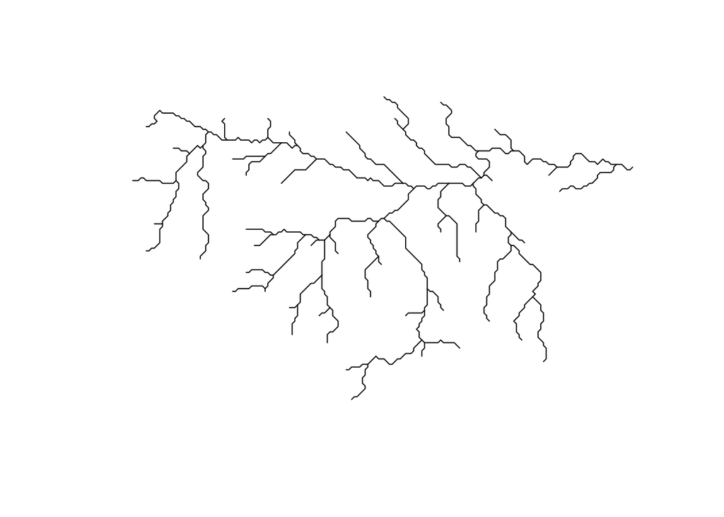

```r
par(mfrow=c(1,1))

plot(red80)
```

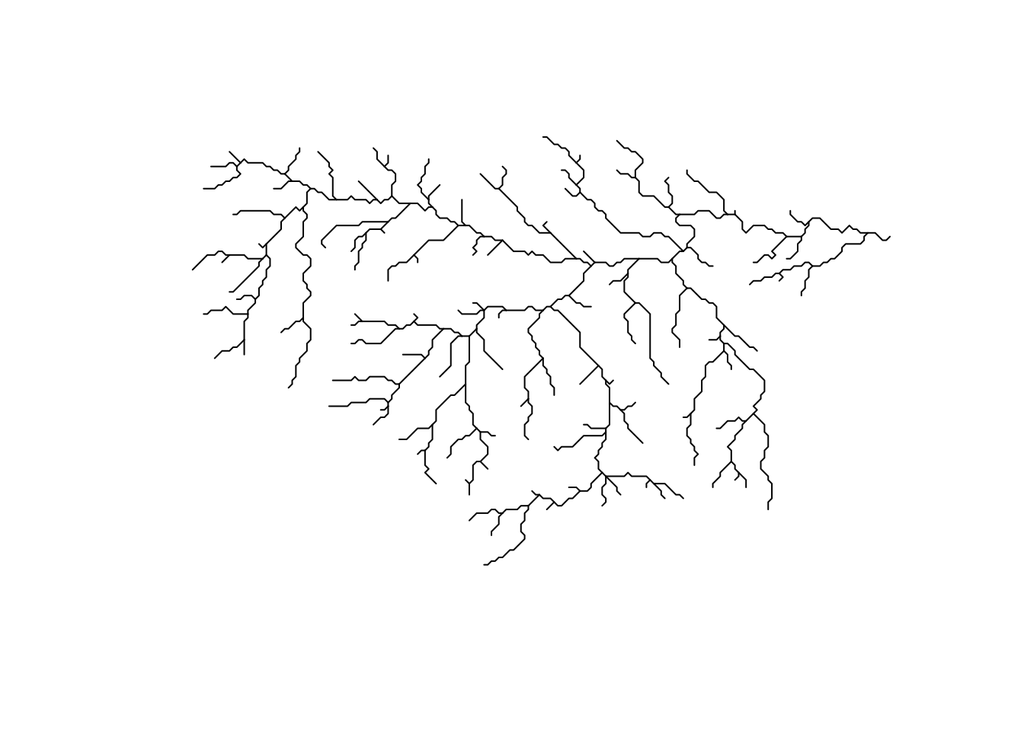

```r
plot(red30)
```

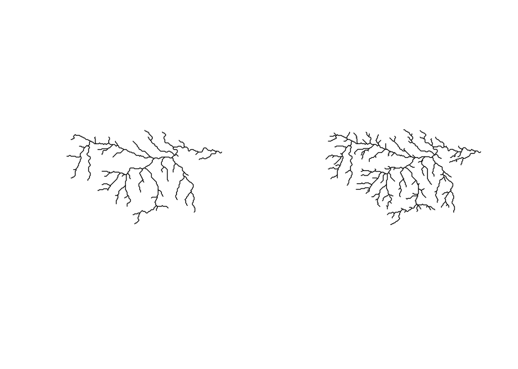

```r
par(mfrow=c(1,2))
plot (red80)

plot(red30)
```

```r
red80ll <- spTransform(red80, CRSobj = CRS("+init=epsg:4326"))
red80ll
## class       : SpatialLinesDataFrame
## features    : 91
## extent      : -70.95034, -70.79283, 19.00249, 19.09328  (xmin, xmax, ymin, ymax)
## crs         : +init=epsg:4326 +proj=longlat +datum=WGS84 +no_defs +ellps=WGS84 +towgs84=0,0,0
## variables   : 4
## names       : cat,  stream_type, type_code, network
## min values  :   1, intermediate,         0,       1
## max values  :  91,        start,         1,       1
red30ll <- spTransform(red30, CRSobj = CRS("+init=epsg:4326"))
red30ll
## class       : SpatialLinesDataFrame
## features    : 213
## extent      : -70.95371, -70.79283, 19.00001, 19.09408  (xmin, xmax, ymin, ymax)
## crs         : +init=epsg:4326 +proj=longlat +datum=WGS84 +no_defs +ellps=WGS84 +towgs84=0,0,0
## variables   : 4
## names       : cat,  stream_type, type_code, network
## min values  :   1, intermediate,         0,       1
## max values  : 213,        start,         1,       1

library(leaflet)
leaflet() %>%
 addPolylines(data = red80ll, weight = 3, opacity = 0.7, group = 'str_vect') %>%
  leafem::addHomeButton(extent(red80ll), 'Ver todo') %>%
  addLayersControl(
    overlayGroups = c('terrain','str_vect','str_raster'),
    options = layersControlOptions(collapsed=FALSE))
```

[interactive chart not shown]

```r
leaflet() %>%
 addPolylines(data = red30ll, weight = 3, opacity = 0.7, group = 'str_vect') %>%
  leafem::addHomeButton(extent(red30ll), 'Ver todo') %>%
  addLayersControl(
    overlayGroups = c('terrain','str_vect','str_raster'),
    options = layersControlOptions(collapsed=FALSE))
```

[interactive chart not shown]

*Describe tus dos redes de drenaje e interprétalas. Algunas preguntas guía: En dos líneas, ¿cómo describirías tus dos redes? ¿Cuál es/son la/s diferencia/s principales entre ambas redes, es decir, entre la generada con umbral 30 y la generada con 80? Clasifica tu tipo de red según morfología, apoyándote en el material de apoyo de la clase (e.g. dendrítica, paralela, etc.) (Gutiérrez Elorza, 2008; Pedraza Gilsanz, 1996).*

Las redes de drenaje de la cuenca río Yaque del Norte son abundante, lo que se asume que en dicha cuenca existe varios afluentes que alimentan el canal principal. Presenta una ramificación amplia, posiblemente sea de tipo angulado; razón de, que sus redes forma ángulos grandes. Posiblemente dichas características sean productos de eventuales fallas tectónicas que puedan existir en la zona. Las redes con diferentes tipos de umbral se notan un poco diferente, la de umbral 30 (red30) presenta más ramificación y forma ángulos más grande con respecto a la red (red80).

# Referencias

Gutiérrez Elorza, M. (2008). *Geomorfología*.

Pedraza Gilsanz, J. de. (1996). *Geomorfología: Principios, métodos y aplicaciones*.